None

# Exercises in coalescent theory

## Exercise A: Simulating a coalescence tree assuming a constant population size

(Based on notes by Ida Moltke)

The purpose of this first exercise is to make sure it is clear how a coalescence tree is simulated.

First, let us try to simulate a coalescence tree for five samples by hand:

1. Start by drawing on a piece of paper a small circle for each of the five samples. They should be lined up on an invisible horizontal line and you should leave enough space above the circles for drawing a tree above them (which we will do shortly). We will henceforth call these five circles "nodes" and label them 1,2,3,4,5

Example:

[figure not shown]

2. Also, make a list of the node names. You can either do this by hand or you can do it in R by simply writing:

```
nodes = c(1,2,3,4,5) # make the list and call it nodes
nodes # print the list
```

[output not shown]

1. 1

2. 2

3. 3

4. 4

5. 5

3. Sample which two nodes will coalesce first (going back in time) by randomly picking two of the nodes. You can either do this by hand or you can do it in R by typing:

```
nodecount = length(nodes) # save the number of nodes in the variable nodecount
tocoalesce = sample(1:nodecount, size=2) # sample 2 different nodes in node list
nodes[tocoalesce[1]] # print the first node sampled
nodes[tocoalesce[2]] # print the second node sampled
```

1

5

4. Sample the time it takes before these two nodes coalesce (measured from previous coalescence event in units of 2N) by sampling from an exponential distribution with rate equal to "nodecount choose 2" (expressed in R as `choose(nodecount,2)` ) where nodecount is the number of nodes in your node list. Do this in R by typing:

```
coalescencerate = choose(nodecount,2) # calculate the coalescent rate
coalescencetime = rexp(1, rate=coalescencerate) # sample from exponential w. that rate
coalescencetime
```

0.112275193068655

Make sure you understand what the R code does before moving on.

5. Now, in your piece of paper, draw a node that is the sampled amount of time further up in the tree than the currently highest node (so if the currently highest node is drawn at height T then draw the new one at height T plus the sampled coalescence time) and draw a branch from each of the nodes you sampled in step 3 to this new node indicating that these two nodes coalesce at this time.

Example:

[figure not shown]

6. Next, make an updated list of the nodes that are left by removing the two nodes that coalesced and instead adding the newly drawn node that represents their common ancestor. You can call the new node the next number not used as a name yet (e.g. if this is the first coalescence event you can call it 6, if it is the second coalescence event you can call it 7 etc.). You can either do this by hand or in R. If you want to do it R you can do it as follows:

```
nodes <- nodes[-tocoalesce] # remove the two nodes that coalesced
nodes <- c(nodes,2*5-length(nodes)-1) # add the new node
nodes # print the new list
```

1. 2

2. 3

3. 4

4. 6

If you used R then make sure you understand what the R code does before moving on.

7. Now lets repeat the above steps until only one node is left in your nodes vector.

```
# five sampled nodes
nodes <- c(1, 2, 3, 4, 5)
# next node (first anc of 2 of the sampled nodes)
next_node <- 6
# loop until only one lineage remains
while (length(nodes) > 1) {
  # # lineages
  nodecount <- length(nodes)
  # choose 2 lineages to coalesce
  tocoalesce <- sample(nodes, size = 2)
  # coalescence rate
  coalescencerate <- choose(nodecount, 2)
  # waiting time until the next coalescence
  coalescencetime <- rexp(1, rate = coalescencerate)
  # print
  cat("Coalescing:", tocoalesce[1], "and", tocoalesce[2], "\n")
  cat("Waiting time:", coalescencetime, "\n\n")
  # remove the lineages that coalesced
  nodes <- nodes[!nodes %in% tocoalesce]
  # add common ancestor of the 2
  nodes <- c(nodes, next_node)
  # go to the next node
  next_node <- next_node + 1
}

# print
nodes
```

```
Coalescing: 4 and 2
Waiting time: 0.05714872

Coalescing: 3 and 1
Waiting time: 0.03039782

Coalescing: 7 and 6
Waiting time: 0.3899896

Coalescing: 5 and 8
Waiting time: 0.2481025
```

9

In the end you should have a tree, which is a simulation of a coalescence tree. Try to do this a couple times until you feel like you know how it is done and understand how the coalescence process works (if after drawing a few trees still don’t understand, then feel free to ask for help!).

## Wright Fisher

### Thinking backwards in time

Start in the present and go backwards in time. Specifically, we'll aim to trace the lineages of particular individuals that exist in the present and see how they "coalesce" (find a common ancestor) in the past.

We will trace the genealogy of 3 lineages in a population of size N = 10 (2N = 20) over 20 generations:

```
source("/course/popgen25/software/simulateWF.R")
```

```
track_lineages(N.vec=rep(10,20), n.iter=1, num.tracked=3)
```

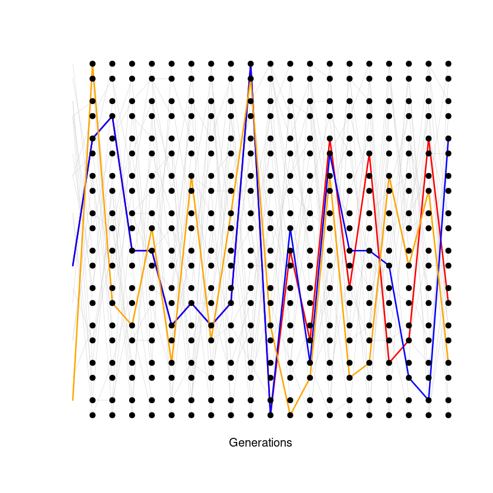

what happens to the coalescence rate, when N = 7 and when N = 20. Do lineages coalesce faster or slower with larger population size?

```
track_lineages(N.vec=rep(7,20), n.iter=1, num.tracked=3)
```

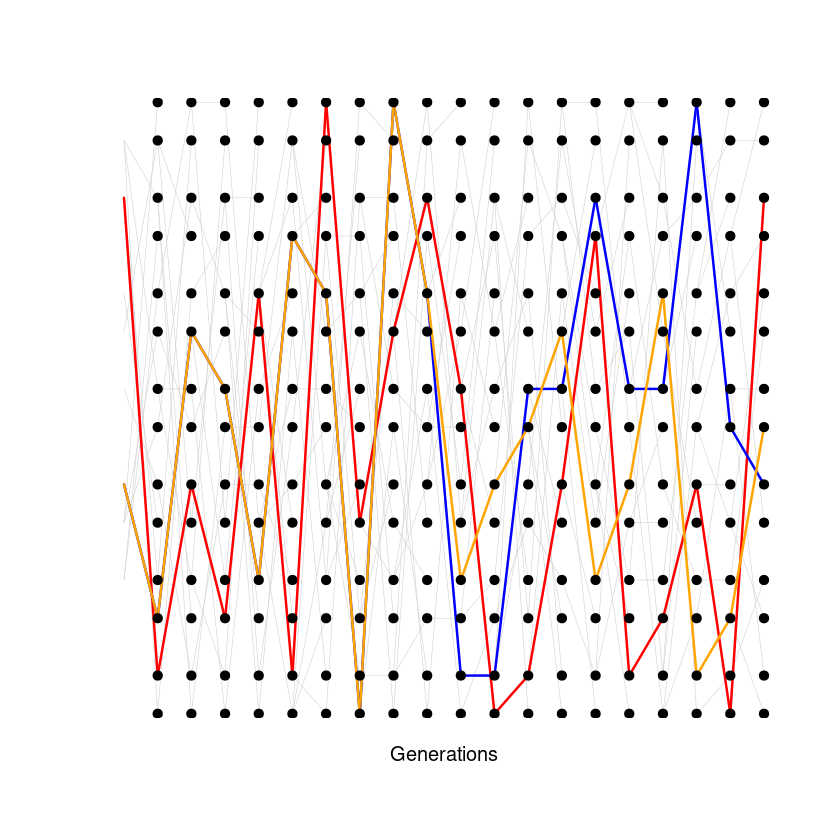

```
track_lineages(N.vec=rep(20,20), n.iter=1, num.tracked=3)
```

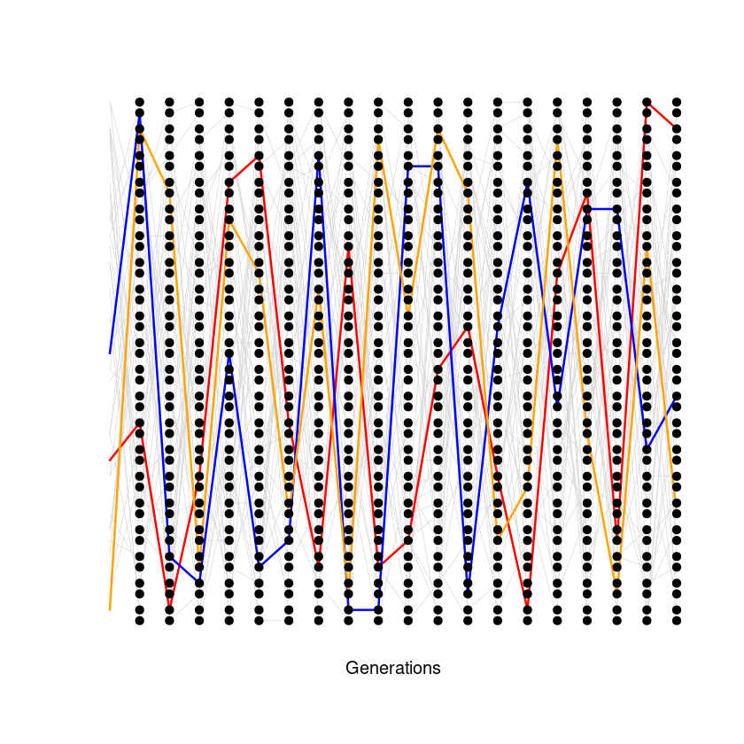